# ROS costs updated

Author

Florent Bédécarrats

Abstract

This analysis aims to provide update and compare the annual budget of rural observatories in Madagascar from 1995 to 1998 with current prices in Malagasy Ariary and Euros. Historical financial data, originally reported in French francs, is converted to Malagasy francs using historical exchange rates. Subsequent adjustments for inflation are made based on annual consumer price indices obtained from the World Bank. The final figures are then converted to Euros using the latest exchange rates.

## Objective

We find the followingreport on the is the original annual budget of the rural observatories from 1995 to 1998 in Droy, Ratovoarinony and Roubaud (2000, 133):

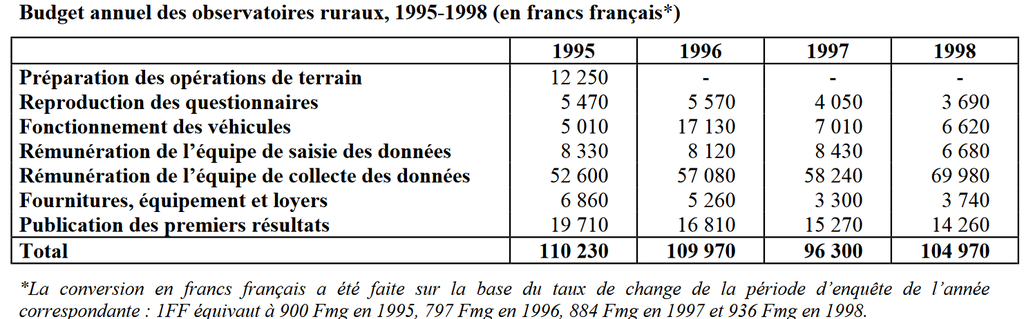

Annual budget of the rural observatories, 1995-1998 in French francs

The objective of this analysis is to update and compare the annual costs of implementing rural observatories in Madagascar from 1995 to 1998 with current prices in Malagasy Ariary and Euros.

The process involves:

- Converting historical costs from French francs to Malagasy francs using historical exchange rates ;
- Adjusting these values for inflation using annual consumer price indices from the World Bank ;
- Converting the inflation-adjusted values to Euros using the latest exchange rates.

## Procedure

### Step 1: enter the original table data

We re-create the budget data by copying the original figure.

```r
# Load tidyverse for easier data manipulation
library(tidyverse)
library(gt)
options(scipen = 999) # on désactive les notations scientifiques
# Data from the image
budget_data1 <- tibble(
  Year = c(1995, 1996, 1997, 1998),
  Preparation_of_field_operations = c(12250, NA, NA, NA),
  Reproduction_of_questionnaires = c(5470, 5570, 4050, 3690),
  Vehicle_running_costs = c(5010, 17130, 7010, 6620),
  Payment_of_team_of_data_loggers = c(8330, 8120, 8430, 6680),
  Payment_of_data_collection_team = c(52600, 57080, 58240, 69980),
  Supplies_equipment_and_rent = c(6860, 5260, 3300, 3740),
  Publication_of_initial_results = c(19710, 16810, 15270, 14260),
  Total = c(110230, 109970, 96300, 104970)
)
gt(budget_data1)
```

| Year | Preparation_of_field_operations | Reproduction_of_questionnaires | Vehicle_running_costs | Payment_of_team_of_data_loggers | Payment_of_data_collection_team | Supplies_equipment_and_rent | Publication_of_initial_results | Total |
| --- | --- | --- | --- | --- | --- | --- | --- | --- |
| 1995 | 12250 | 5470 | 5010 | 8330 | 52600 | 6860 | 19710 | 110230 |
| 1996 | NA | 5570 | 17130 | 8120 | 57080 | 5260 | 16810 | 109970 |
| 1997 | NA | 4050 | 7010 | 8430 | 58240 | 3300 | 15270 | 96300 |
| 1998 | NA | 3690 | 6620 | 6680 | 69980 | 3740 | 14260 | 104970 |

## Step 2: Convert French Francs to Malagasy Francs

Note that both currency have been discarded for Euros and Ariary respectively.

```r
# Exchange rates
exchange_rates <- tibble(
  Year = c(1995, 1996, 1997, 1998),
  Exchange_Rate = c(900, 797, 884, 936)
)

# Join exchange rates and convert French francs to Malagasy francs
budget_data2 <- budget_data1 %>%
  left_join(exchange_rates, by = "Year") %>%
  mutate(across(starts_with("Preparation_of_field_operations"):starts_with("Total"),
                ~ .x * Exchange_Rate))
gt(budget_data2)
```

| Year | Preparation_of_field_operations | Reproduction_of_questionnaires | Vehicle_running_costs | Payment_of_team_of_data_loggers | Payment_of_data_collection_team | Supplies_equipment_and_rent | Publication_of_initial_results | Total | Exchange_Rate |
| --- | --- | --- | --- | --- | --- | --- | --- | --- | --- |
| 1995 | 11025000 | 4923000 | 4509000 | 7497000 | 47340000 | 6174000 | 17739000 | 99207000 | 900 |
| 1996 | NA | 4439290 | 13652610 | 6471640 | 45492760 | 4192220 | 13397570 | 87646090 | 797 |
| 1997 | NA | 3580200 | 6196840 | 7452120 | 51484160 | 2917200 | 13498680 | 85129200 | 884 |
| 1998 | NA | 3453840 | 6196320 | 6252480 | 65501280 | 3500640 | 13347360 | 98251920 | 936 |

## Step 3: Retrieve inflation data from World Bank

We use the WDI package and download the indicator named “Inflation, consumer prices (annual %) - Madagascar”, originates from the International Monetary Fund according to the dataset metadata: https://data.worldbank.org/indicator/FP.CPI.TOTL.ZG?locations=MG

```r
# Load the World data indicator package to query world bank API
library(WDI)
# Download inflation data from the World Bank
if (!file.exists("inflation_data.rds")) {
  inflation_data <- WDI(country = "MG", indicator = "FP.CPI.TOTL.ZG", start = 1995, end = 2023) %>%
  rename(Year = year, Inflation = FP.CPI.TOTL.ZG)
write_rds(inflation_data, "inflation_data.rds")
} else {
  inflation_data <- read_rds("inflation_data.rds")
}
```

## Step 4: Apply inflation rates and convert to Ariary

As of date, the most recent year for annual inflation is 2023. Conversion factor from Malagasy franc to Ariary is 1 Ariary = 5 Malagasy francs.

```r
# Calculate cumulative inflation from the year to the most recent year
current_year <- max(inflation_data$Year)
cumulative_inflation <- inflation_data %>%
  filter(Year >= 1995) %>%
  arrange(desc(Year)) %>%
  mutate(Cumulative_Inflation = cumprod(1 + Inflation / 100)) %>%
  arrange(Year)

# Apply cumulative inflation to convert Malagasy francs to current Ariary
budget_data3 <- budget_data2 %>%
  left_join(cumulative_inflation, by = "Year") %>%
  mutate(across(starts_with("Preparation_of_field_operations"):starts_with("Total"),
                ~ .x * Cumulative_Inflation / 5))

gt(budget_data3)
```

| Year | Preparation_of_field_operations | Reproduction_of_questionnaires | Vehicle_running_costs | Payment_of_team_of_data_loggers | Payment_of_data_collection_team | Supplies_equipment_and_rent | Publication_of_initial_results | Total | Exchange_Rate | country | iso2c | iso3c | Inflation, consumer prices (annual %) | Cumulative_Inflation |
| --- | --- | --- | --- | --- | --- | --- | --- | --- | --- | --- | --- | --- | --- | --- |
| 1995 | 34368751 | 15346699 | 14056118 | 23370751 | 147575208 | 19246500 | 55298619 | 309262646 | 900 | Madagascar | MG | MDG | 49.080210 | 15.586735 |
| 1996 | NA | 9282793 | 28548339 | 13532546 | 95127797 | 8766156 | 28015036 | 183272667 | 797 | Madagascar | MG | MDG | 19.756355 | 10.455268 |
| 1997 | NA | 6251351 | 10820239 | 13012071 | 89895969 | 5093693 | 23569908 | 148643232 | 884 | Madagascar | MG | MDG | 4.486383 | 8.730449 |
| 1998 | NA | 5771771 | 10354777 | 10448626 | 109460311 | 5849979 | 22305002 | 164190467 | 936 | Madagascar | MG | MDG | 6.208016 | 8.355586 |

## Step 5: Convert to euros

```r
if (!file.exists("exchange_rate_usd.rds")) {
  # Fetch the most recent exchange rate from MGA to USD
  exchange_rate_usd <- WDI(country = "MG", indicator = "PA.NUS.FCRF", start = 2023, end = 2023) %>%
    rename(Year = year, Exchange_Rate_to_USD = PA.NUS.FCRF)
  write_rds(exchange_rate_usd, "exchange_rate_usd.rds")
} else {
  exchange_rate_usd <- read_rds("exchange_rate_usd.rds")
}
if (!file.exists("exchange_rate_euro.rds")) {
  # Fetch the most recent exchange rate from USD to Euro
  exchange_rate_euro <- WDI(country = "FR", indicator = "PA.NUS.FCRF", start = 2023, end = 2023) %>%
    rename(Year = year, Exchange_Rate_to_Euro = PA.NUS.FCRF)
  write_rds(exchange_rate_euro, "exchange_rate_euro.rds")
} else {
  exchange_rate_euro <- read_rds("exchange_rate_euro.rds")
}

# Calculate the exchange rate from MGA to Euro
ariary_to_euro <- exchange_rate_usd$Exchange_Rate_to_USD *
  (1 / exchange_rate_euro$Exchange_Rate_to_Euro)

# Convert to Euros
budget_data_euros <- budget_data3 %>%
  mutate(across(starts_with("Preparation_of_field_operations"):starts_with("Total"),
                ~ .x / ariary_to_euro))
gt(budget_data_euros)
```

| Year | Preparation_of_field_operations | Reproduction_of_questionnaires | Vehicle_running_costs | Payment_of_team_of_data_loggers | Payment_of_data_collection_team | Supplies_equipment_and_rent | Publication_of_initial_results | Total | Exchange_Rate | country | iso2c | iso3c | Inflation, consumer prices (annual %) | Cumulative_Inflation |
| --- | --- | --- | --- | --- | --- | --- | --- | --- | --- | --- | --- | --- | --- | --- |
| 1995 | 7175.756 | 3204.195 | 2934.738 | 4879.514 | 30811.82 | 4018.423 | 11545.645 | 64570.09 | 900 | Madagascar | MG | MDG | 49.080210 | 15.586735 |
| 1996 | NA | 1938.129 | 5960.528 | 2825.423 | 19861.47 | 1830.262 | 5849.182 | 38264.99 | 797 | Madagascar | MG | MDG | 19.756355 | 10.455268 |
| 1997 | NA | 1305.202 | 2259.128 | 2716.754 | 18769.13 | 1063.498 | 4921.096 | 31034.81 | 884 | Madagascar | MG | MDG | 4.486383 | 8.730449 |
| 1998 | NA | 1205.072 | 2161.945 | 2181.540 | 22853.91 | 1221.401 | 4657.000 | 34280.87 | 936 | Madagascar | MG | MDG | 6.208016 | 8.355586 |

## Complement: other values from an other source

David-Benz et al. report the following (2010, 36): “*Le coût annuel du ROR s’élève actuellement à 210 000 eur (pour 15 observatoires)*”. They do not specify which year this corresponds to, but the report was published in January 2010, there was no data collection in 2009 (political crisis in Madagascar) and the latest year in which there was 15 observatories was 2006, so we assume that it corresponds to 2006.

We convert this amount to 2006 Ariary, update with the cumulative inflation since 2007 and convert back to euros with 2023 currency rate.

```r
# Define the reported cost in 2006 euros
reported_cost_eur_2006 <- 210000

if (!file.exists("exchange_rate_eur_to_usd_2006.rds")) {
  # Fetch the exchange rate from Euro to USD for 2006
  exchange_rate_eur_to_usd_2006 <- WDI(country = "FR", indicator = "PA.NUS.FCRF",
                                       start = 2006, end = 2006) %>%
    pull(PA.NUS.FCRF)
  write_rds(exchange_rate_usd_to_eur_2006, "exchange_rate_eur_to_usd_2006.rds")
  # Fetch the exchange rate from USD to MGA for 2006
  exchange_rate_usd_to_mga_2006 <- WDI(country = "MG", indicator = "PA.NUS.FCRF",
                                       start = 2006, end = 2006) %>%
    pull(PA.NUS.FCRF)
  write_rds(exchange_rate_usd_to_mga_2006, "exchange_rate_usd_to_mga_2006.rds")
} else {
  exchange_rate_eur_to_usd_2006 <- read_rds("exchange_rate_eur_to_usd_2006.rds")
  exchange_rate_usd_to_mga_2006 <- read_rds("exchange_rate_usd_to_mga_2006.rds")
}

# Convert the reported cost from euros to USD for 2006
reported_cost_usd_2006 <- reported_cost_eur_2006 * (1/exchange_rate_eur_to_usd_2006)

# Convert the reported cost from USD to MGA for 2006
reported_cost_mga_2006 <- reported_cost_usd_2006 * exchange_rate_usd_to_mga_2006

# Fetch the cumulative inflation from 2007 to 2023
cumulative_inflation_2007_to_2023 <- inflation_data %>%
  filter(Year >= 2007) %>%
  arrange(Year) %>%
  mutate(Cumulative_Inflation = cumprod(1 + Inflation / 100)) %>%
  filter(Year == 2023) %>%
  pull(Cumulative_Inflation)

# Update the 2006 MGA cost with cumulative inflation to 2023
reported_cost_mga_2023 <- reported_cost_mga_2006 * cumulative_inflation_2007_to_2023

# Convert the updated MGA cost back to euros using the 2023 exchange rate
reported_cost_eur_2023 <- reported_cost_mga_2023 / ariary_to_euro

# Print the updated cost in 2023 euros
reported_cost_eur_2023
```

```
[1] 408676.8
attr(,"label")
[1] "Official exchange rate (LCU per US$, period average)"
```

```r
# Print the updated 2023 cost per observatory in euros
cost_per_obs_2023 <- reported_cost_eur_2023 / 15
cost_per_obs_2023
```

```
[1] 27245.12
attr(,"label")
[1] "Official exchange rate (LCU per US$, period average)"
```

```r
# Print the cost per household
cost_per_obs_2023 / 500
```

```
[1] 54.49024
attr(,"label")
[1] "Official exchange rate (LCU per US$, period average)"
```

## References

David-Benz, Hélène, Michel Benoit-Cattin, and Rivo Ramboarison. 2010. *Evaluation Du Réseau Des Observatoires Ruraux à Madagascar*. Montpellier: CIRAD. https://agritrop.cirad.fr/558679/1/document_558679.pdf.

Droy, Isabelle, Raphaël Ratovoarinony, and François Roubaud. 2000. “Les Observatoires Ruraux à Madagascar. Une Méthodologie Originale Pour Le Suivi Des Campagnes.” *Stateco* 95: 123140.